# Risk Factor Analysis

## Outcome Variable

**Outcome Variable:** wast_rec90d

## Predictor Variables

**Intervention Variable:** meducyrs

**Adjustment Set:**

- arm
- W_mage
- feducyrs
- hhwealth_quart
- W_mhtcm
- W_gagebrth
- W_birthwt
- W_birthlen
- W_nrooms
- impfloor
- impsan
- safeh20
- delta_W_mage
- delta_feducyrs
- delta_hhwealth_quart
- delta_W_mhtcm
- delta_W_gagebrth
- delta_W_birthwt
- delta_W_birthlen
- delta_W_nrooms
- delta_impfloor
- delta_impsan
- delta_safeh20

## Stratifying Variables

The analysis was stratified on these variable(s):

- agecat
- studyid
- country

## Data Summary

| agecat | studyid | country | meducyrs | wast_rec90d | n_cell | n |
| --- | --- | --- | --- | --- | --- | --- |
| 0-24 months | ki0047075b-MAL-ED | BANGLADESH | Low | 0 | 10 | 86 |
| 0-24 months | ki0047075b-MAL-ED | BANGLADESH | Low | 1 | 22 | 86 |
| 0-24 months | ki0047075b-MAL-ED | BANGLADESH | Medium | 0 | 6 | 86 |
| 0-24 months | ki0047075b-MAL-ED | BANGLADESH | Medium | 1 | 21 | 86 |
| 0-24 months | ki0047075b-MAL-ED | BANGLADESH | High | 0 | 7 | 86 |
| 0-24 months | ki0047075b-MAL-ED | BANGLADESH | High | 1 | 20 | 86 |
| 0-24 months | ki0047075b-MAL-ED | BRAZIL | Low | 0 | 4 | 23 |
| 0-24 months | ki0047075b-MAL-ED | BRAZIL | Low | 1 | 6 | 23 |
| 0-24 months | ki0047075b-MAL-ED | BRAZIL | Medium | 0 | 2 | 23 |
| 0-24 months | ki0047075b-MAL-ED | BRAZIL | Medium | 1 | 8 | 23 |
| 0-24 months | ki0047075b-MAL-ED | BRAZIL | High | 0 | 0 | 23 |
| 0-24 months | ki0047075b-MAL-ED | BRAZIL | High | 1 | 3 | 23 |
| 0-24 months | ki0047075b-MAL-ED | INDIA | Low | 0 | 21 | 153 |
| 0-24 months | ki0047075b-MAL-ED | INDIA | Low | 1 | 42 | 153 |
| 0-24 months | ki0047075b-MAL-ED | INDIA | Medium | 0 | 25 | 153 |
| 0-24 months | ki0047075b-MAL-ED | INDIA | Medium | 1 | 34 | 153 |
| 0-24 months | ki0047075b-MAL-ED | INDIA | High | 0 | 12 | 153 |
| 0-24 months | ki0047075b-MAL-ED | INDIA | High | 1 | 19 | 153 |
| 0-24 months | ki0047075b-MAL-ED | NEPAL | Low | 0 | 5 | 88 |
| 0-24 months | ki0047075b-MAL-ED | NEPAL | Low | 1 | 28 | 88 |
| 0-24 months | ki0047075b-MAL-ED | NEPAL | Medium | 0 | 10 | 88 |
| 0-24 months | ki0047075b-MAL-ED | NEPAL | Medium | 1 | 29 | 88 |
| 0-24 months | ki0047075b-MAL-ED | NEPAL | High | 0 | 2 | 88 |
| 0-24 months | ki0047075b-MAL-ED | NEPAL | High | 1 | 14 | 88 |
| 0-24 months | ki0047075b-MAL-ED | PERU | Low | 0 | 2 | 34 |
| 0-24 months | ki0047075b-MAL-ED | PERU | Low | 1 | 14 | 34 |
| 0-24 months | ki0047075b-MAL-ED | PERU | Medium | 0 | 4 | 34 |
| 0-24 months | ki0047075b-MAL-ED | PERU | Medium | 1 | 11 | 34 |
| 0-24 months | ki0047075b-MAL-ED | PERU | High | 0 | 0 | 34 |
| 0-24 months | ki0047075b-MAL-ED | PERU | High | 1 | 3 | 34 |

[output cut: 438 more lines]

The following strata were considered:

- agecat: 0-24 months, studyid: ki0047075b-MAL-ED, country: BANGLADESH
- agecat: 0-24 months, studyid: ki0047075b-MAL-ED, country: BRAZIL
- agecat: 0-24 months, studyid: ki0047075b-MAL-ED, country: INDIA
- agecat: 0-24 months, studyid: ki0047075b-MAL-ED, country: NEPAL
- agecat: 0-24 months, studyid: ki0047075b-MAL-ED, country: PERU
- agecat: 0-24 months, studyid: ki0047075b-MAL-ED, country: SOUTH AFRICA
- agecat: 0-24 months, studyid: ki0047075b-MAL-ED, country: TANZANIA, UNITED REPUBLIC OF
- agecat: 0-24 months, studyid: ki1000108-CMC-V-BCS-2002, country: INDIA
- agecat: 0-24 months, studyid: ki1000108-IRC, country: INDIA
- agecat: 0-24 months, studyid: ki1000109-EE, country: PAKISTAN
- agecat: 0-24 months, studyid: ki1000304b-SAS-CompFeed, country: INDIA
- agecat: 0-24 months, studyid: ki1000304b-SAS-FoodSuppl, country: INDIA
- agecat: 0-24 months, studyid: ki1017093-NIH-Birth, country: BANGLADESH
- agecat: 0-24 months, studyid: ki1017093b-PROVIDE, country: BANGLADESH
- agecat: 0-24 months, studyid: ki1017093c-NIH-Crypto, country: BANGLADESH
- agecat: 0-24 months, studyid: ki1066203-TanzaniaChild2, country: TANZANIA, UNITED REPUBLIC OF
- agecat: 0-24 months, studyid: ki1112895-Guatemala BSC, country: GUATEMALA
- agecat: 0-24 months, studyid: ki1113344-GMS-Nepal, country: NEPAL
- agecat: 0-24 months, studyid: ki1119695-PROBIT, country: BELARUS
- agecat: 0-24 months, studyid: ki1126311-ZVITAMBO, country: ZIMBABWE
- agecat: 0-24 months, studyid: ki1135781-COHORTS, country: GUATEMALA
- agecat: 0-24 months, studyid: ki1135781-COHORTS, country: INDIA
- agecat: 0-24 months, studyid: ki1135781-COHORTS, country: PHILIPPINES
- agecat: 0-24 months, studyid: ki1148112-LCNI-5, country: MALAWI
- agecat: 0-24 months, studyid: kiGH5241-JiVitA-3, country: BANGLADESH
- agecat: 0-24 months, studyid: kiGH5241-JiVitA-4, country: BANGLADESH
- agecat: 0-6 months, studyid: ki0047075b-MAL-ED, country: BANGLADESH
- agecat: 0-6 months, studyid: ki0047075b-MAL-ED, country: BRAZIL
- agecat: 0-6 months, studyid: ki0047075b-MAL-ED, country: INDIA
- agecat: 0-6 months, studyid: ki0047075b-MAL-ED, country: NEPAL
- agecat: 0-6 months, studyid: ki0047075b-MAL-ED, country: PERU
- agecat: 0-6 months, studyid: ki0047075b-MAL-ED, country: SOUTH AFRICA
- agecat: 0-6 months, studyid: ki0047075b-MAL-ED, country: TANZANIA, UNITED REPUBLIC OF
- agecat: 0-6 months, studyid: ki1000108-CMC-V-BCS-2002, country: INDIA
- agecat: 0-6 months, studyid: ki1000108-IRC, country: INDIA
- agecat: 0-6 months, studyid: ki1000109-EE, country: PAKISTAN
- agecat: 0-6 months, studyid: ki1000304b-SAS-CompFeed, country: INDIA
- agecat: 0-6 months, studyid: ki1000304b-SAS-FoodSuppl, country: INDIA
- agecat: 0-6 months, studyid: ki1017093-NIH-Birth, country: BANGLADESH
- agecat: 0-6 months, studyid: ki1017093b-PROVIDE, country: BANGLADESH
- agecat: 0-6 months, studyid: ki1017093c-NIH-Crypto, country: BANGLADESH
- agecat: 0-6 months, studyid: ki1066203-TanzaniaChild2, country: TANZANIA, UNITED REPUBLIC OF
- agecat: 0-6 months, studyid: ki1112895-Guatemala BSC, country: GUATEMALA
- agecat: 0-6 months, studyid: ki1113344-GMS-Nepal, country: NEPAL
- agecat: 0-6 months, studyid: ki1119695-PROBIT, country: BELARUS
- agecat: 0-6 months, studyid: ki1126311-ZVITAMBO, country: ZIMBABWE
- agecat: 0-6 months, studyid: ki1135781-COHORTS, country: GUATEMALA
- agecat: 0-6 months, studyid: ki1135781-COHORTS, country: INDIA
- agecat: 0-6 months, studyid: ki1135781-COHORTS, country: PHILIPPINES
- agecat: 0-6 months, studyid: ki1148112-LCNI-5, country: MALAWI
- agecat: 0-6 months, studyid: kiGH5241-JiVitA-3, country: BANGLADESH
- agecat: 0-6 months, studyid: kiGH5241-JiVitA-4, country: BANGLADESH
- agecat: 6-24 months, studyid: ki0047075b-MAL-ED, country: BANGLADESH
- agecat: 6-24 months, studyid: ki0047075b-MAL-ED, country: BRAZIL
- agecat: 6-24 months, studyid: ki0047075b-MAL-ED, country: INDIA
- agecat: 6-24 months, studyid: ki0047075b-MAL-ED, country: NEPAL
- agecat: 6-24 months, studyid: ki0047075b-MAL-ED, country: PERU
- agecat: 6-24 months, studyid: ki0047075b-MAL-ED, country: SOUTH AFRICA
- agecat: 6-24 months, studyid: ki0047075b-MAL-ED, country: TANZANIA, UNITED REPUBLIC OF
- agecat: 6-24 months, studyid: ki1000108-CMC-V-BCS-2002, country: INDIA
- agecat: 6-24 months, studyid: ki1000108-IRC, country: INDIA
- agecat: 6-24 months, studyid: ki1000109-EE, country: PAKISTAN
- agecat: 6-24 months, studyid: ki1000304b-SAS-CompFeed, country: INDIA
- agecat: 6-24 months, studyid: ki1000304b-SAS-FoodSuppl, country: INDIA
- agecat: 6-24 months, studyid: ki1017093-NIH-Birth, country: BANGLADESH
- agecat: 6-24 months, studyid: ki1017093b-PROVIDE, country: BANGLADESH
- agecat: 6-24 months, studyid: ki1017093c-NIH-Crypto, country: BANGLADESH
- agecat: 6-24 months, studyid: ki1066203-TanzaniaChild2, country: TANZANIA, UNITED REPUBLIC OF
- agecat: 6-24 months, studyid: ki1112895-Guatemala BSC, country: GUATEMALA
- agecat: 6-24 months, studyid: ki1113344-GMS-Nepal, country: NEPAL
- agecat: 6-24 months, studyid: ki1119695-PROBIT, country: BELARUS
- agecat: 6-24 months, studyid: ki1126311-ZVITAMBO, country: ZIMBABWE
- agecat: 6-24 months, studyid: ki1135781-COHORTS, country: GUATEMALA
- agecat: 6-24 months, studyid: ki1135781-COHORTS, country: INDIA
- agecat: 6-24 months, studyid: ki1135781-COHORTS, country: PHILIPPINES
- agecat: 6-24 months, studyid: ki1148112-LCNI-5, country: MALAWI
- agecat: 6-24 months, studyid: kiGH5241-JiVitA-3, country: BANGLADESH
- agecat: 6-24 months, studyid: kiGH5241-JiVitA-4, country: BANGLADESH

### Dropped Strata

Some strata were dropped due to rare outcomes:

- agecat: 0-24 months, studyid: ki0047075b-MAL-ED, country: BRAZIL
- agecat: 0-24 months, studyid: ki0047075b-MAL-ED, country: NEPAL
- agecat: 0-24 months, studyid: ki0047075b-MAL-ED, country: PERU
- agecat: 0-24 months, studyid: ki0047075b-MAL-ED, country: SOUTH AFRICA
- agecat: 0-24 months, studyid: ki0047075b-MAL-ED, country: TANZANIA, UNITED REPUBLIC OF
- agecat: 0-24 months, studyid: ki1000109-EE, country: PAKISTAN
- agecat: 0-24 months, studyid: ki1000304b-SAS-FoodSuppl, country: INDIA
- agecat: 0-24 months, studyid: ki1112895-Guatemala BSC, country: GUATEMALA
- agecat: 0-24 months, studyid: ki1148112-LCNI-5, country: MALAWI
- agecat: 0-6 months, studyid: ki0047075b-MAL-ED, country: BANGLADESH
- agecat: 0-6 months, studyid: ki0047075b-MAL-ED, country: BRAZIL
- agecat: 0-6 months, studyid: ki0047075b-MAL-ED, country: NEPAL
- agecat: 0-6 months, studyid: ki0047075b-MAL-ED, country: PERU
- agecat: 0-6 months, studyid: ki0047075b-MAL-ED, country: SOUTH AFRICA
- agecat: 0-6 months, studyid: ki0047075b-MAL-ED, country: TANZANIA, UNITED REPUBLIC OF
- agecat: 0-6 months, studyid: ki1000109-EE, country: PAKISTAN
- agecat: 0-6 months, studyid: ki1000304b-SAS-FoodSuppl, country: INDIA
- agecat: 0-6 months, studyid: ki1066203-TanzaniaChild2, country: TANZANIA, UNITED REPUBLIC OF
- agecat: 0-6 months, studyid: ki1112895-Guatemala BSC, country: GUATEMALA
- agecat: 0-6 months, studyid: ki1148112-LCNI-5, country: MALAWI
- agecat: 6-24 months, studyid: ki0047075b-MAL-ED, country: BANGLADESH
- agecat: 6-24 months, studyid: ki0047075b-MAL-ED, country: BRAZIL
- agecat: 6-24 months, studyid: ki0047075b-MAL-ED, country: NEPAL
- agecat: 6-24 months, studyid: ki0047075b-MAL-ED, country: PERU
- agecat: 6-24 months, studyid: ki0047075b-MAL-ED, country: SOUTH AFRICA
- agecat: 6-24 months, studyid: ki0047075b-MAL-ED, country: TANZANIA, UNITED REPUBLIC OF
- agecat: 6-24 months, studyid: ki1000109-EE, country: PAKISTAN
- agecat: 6-24 months, studyid: ki1000304b-SAS-FoodSuppl, country: INDIA
- agecat: 6-24 months, studyid: ki1017093c-NIH-Crypto, country: BANGLADESH
- agecat: 6-24 months, studyid: ki1112895-Guatemala BSC, country: GUATEMALA
- agecat: 6-24 months, studyid: ki1135781-COHORTS, country: GUATEMALA
- agecat: 6-24 months, studyid: ki1135781-COHORTS, country: INDIA
- agecat: 6-24 months, studyid: ki1148112-LCNI-5, country: MALAWI
- agecat: 6-24 months, studyid: kiGH5241-JiVitA-3, country: BANGLADESH
- agecat: 6-24 months, studyid: kiGH5241-JiVitA-4, country: BANGLADESH

## Methods Detail

We’re interested in the causal parameters $E[Y_a]$ for all values of $a \in \mathcal{A}$. These parameters represent the mean outcome if, possibly contrary to fact, we intervened to set all units to have $A=a$. Under the randomization and positivity assumptions, these are identified by the statistical parameters $\psi_a=E_W[E_{Y|A,W}(Y|A=a,W)]$. In addition, we’re interested in the mean of $Y$, $E[Y]$ under no intervention (the observed mean). We will estimate these parameters by using SuperLearner to fit the relevant likelihood factors – $E_{Y|A,W}(Y|A=a,W)$ and $p(A=a|W)$, and then updating our likelihood fit using a joint TMLE.

For unadjusted analyses ($W=\{\}$), initial likelihoods were estimated using Lrnr_glm to estimate the simple $E(Y|A)$ and Lrnr_mean to estimate $p(A)$. For adjusted analyses, a small library containing Lrnr_glmnet, Lrnr_xgboost, and Lrnr_mean was used.

Having estimated these parameters, we will then use the delta method to estimate relative risks and attributable risks relative to a prespecified baseline level of $A$.

# Results Detail

## Results Plots

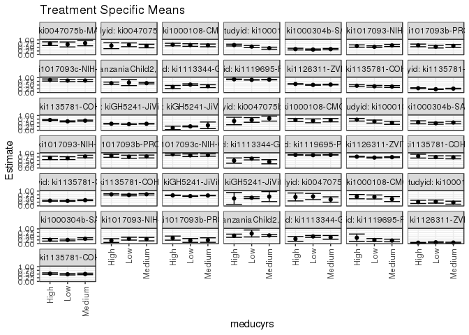

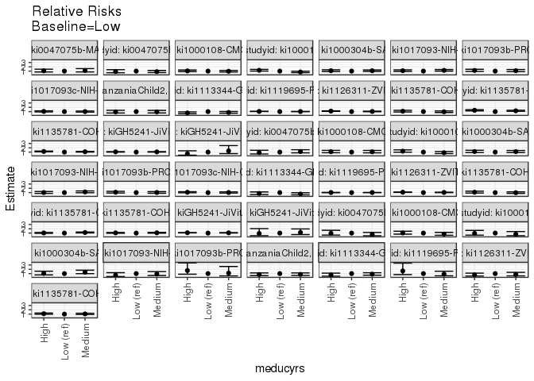

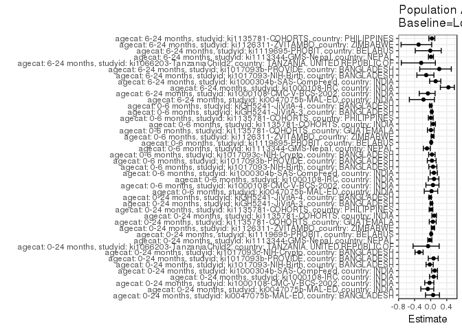

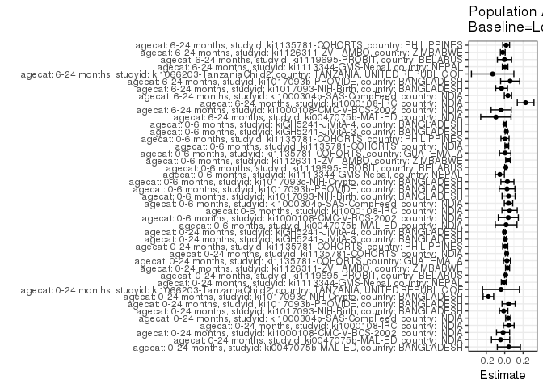

## Results Table

### Parameter: TSM

| agecat | studyid | country | intervention_level | baseline_level | estimate | ci_lower | ci_upper |
| --- | --- | --- | --- | --- | --- | --- | --- |
| 0-24 months | ki0047075b-MAL-ED | BANGLADESH | Low | NA | 0.6875000 | 0.5204085 | 0.8545915 |
| 0-24 months | ki0047075b-MAL-ED | BANGLADESH | Medium | NA | 0.7777778 | 0.5988250 | 0.9567305 |
| 0-24 months | ki0047075b-MAL-ED | BANGLADESH | High | NA | 0.7407407 | 0.6174221 | 0.8640594 |
| 0-24 months | ki0047075b-MAL-ED | INDIA | Low | NA | 0.6655732 | 0.5373001 | 0.7938462 |
| 0-24 months | ki0047075b-MAL-ED | INDIA | Medium | NA | 0.5825744 | 0.4628599 | 0.7022888 |
| 0-24 months | ki0047075b-MAL-ED | INDIA | High | NA | 0.6059071 | 0.4042312 | 0.8075830 |
| 0-24 months | ki1000108-CMC-V-BCS-2002 | INDIA | Low | NA | 0.6497300 | 0.5632036 | 0.7362565 |
| 0-24 months | ki1000108-CMC-V-BCS-2002 | INDIA | Medium | NA | 0.6250405 | 0.5345261 | 0.7155549 |
| 0-24 months | ki1000108-CMC-V-BCS-2002 | INDIA | High | NA | 0.6812727 | 0.5942637 | 0.7682817 |
| 0-24 months | ki1000108-IRC | INDIA | Low | NA | 0.5456954 | 0.4713613 | 0.6200295 |
| 0-24 months | ki1000108-IRC | INDIA | Medium | NA | 0.4336951 | 0.3636508 | 0.5037395 |
| 0-24 months | ki1000108-IRC | INDIA | High | NA | 0.6464052 | 0.5861067 | 0.7067036 |
| 0-24 months | ki1000304b-SAS-CompFeed | INDIA | Low | NA | 0.3425659 | 0.3023068 | 0.3828250 |
| 0-24 months | ki1000304b-SAS-CompFeed | INDIA | Medium | NA | 0.3717652 | 0.3272580 | 0.4162724 |
| 0-24 months | ki1000304b-SAS-CompFeed | INDIA | High | NA | 0.3740078 | 0.3184261 | 0.4295895 |
| 0-24 months | ki1017093-NIH-Birth | BANGLADESH | Low | NA | 0.5316555 | 0.4714926 | 0.5918184 |
| 0-24 months | ki1017093-NIH-Birth | BANGLADESH | Medium | NA | 0.6217220 | 0.5484698 | 0.6949742 |
| 0-24 months | ki1017093-NIH-Birth | BANGLADESH | High | NA | 0.5822033 | 0.5035647 | 0.6608420 |
| 0-24 months | ki1017093b-PROVIDE | BANGLADESH | Low | NA | 0.5406650 | 0.4499144 | 0.6314156 |
| 0-24 months | ki1017093b-PROVIDE | BANGLADESH | Medium | NA | 0.5900931 | 0.4950511 | 0.6851350 |
| 0-24 months | ki1017093b-PROVIDE | BANGLADESH | High | NA | 0.6233026 | 0.5333765 | 0.7132287 |
| 0-24 months | ki1017093c-NIH-Crypto | BANGLADESH | Low | NA | 0.8014433 | 0.7314147 | 0.8714719 |
| 0-24 months | ki1017093c-NIH-Crypto | BANGLADESH | Medium | NA | 0.8032336 | 0.7403345 | 0.8661326 |
| 0-24 months | ki1017093c-NIH-Crypto | BANGLADESH | High | NA | 0.8393157 | 0.7682100 | 0.9104214 |
| 0-24 months | ki1066203-TanzaniaChild2 | TANZANIA, UNITED REPUBLIC OF | Low | NA | 0.6666667 | 0.4628279 | 0.8705055 |
| 0-24 months | ki1066203-TanzaniaChild2 | TANZANIA, UNITED REPUBLIC OF | Medium | NA | 0.6254902 | 0.5809696 | 0.6700108 |
| 0-24 months | ki1066203-TanzaniaChild2 | TANZANIA, UNITED REPUBLIC OF | High | NA | 0.6235955 | 0.5481204 | 0.6990706 |
| 0-24 months | ki1113344-GMS-Nepal | NEPAL | Low | NA | 0.5314831 | 0.4809831 | 0.5819831 |
| 0-24 months | ki1113344-GMS-Nepal | NEPAL | Medium | NA | 0.4247917 | 0.3277404 | 0.5218431 |
| 0-24 months | ki1113344-GMS-Nepal | NEPAL | High | NA | 0.3662862 | 0.2616507 | 0.4709216 |

[output cut: 99 more lines]

### Parameter: E(Y)

| agecat | studyid | country | intervention_level | baseline_level | estimate | ci_lower | ci_upper |
| --- | --- | --- | --- | --- | --- | --- | --- |
| 0-24 months | ki0047075b-MAL-ED | BANGLADESH | NA | NA | 0.7325581 | 0.6399608 | 0.8251555 |
| 0-24 months | ki0047075b-MAL-ED | INDIA | NA | NA | 0.6209150 | 0.5357837 | 0.7060464 |
| 0-24 months | ki1000108-CMC-V-BCS-2002 | INDIA | NA | NA | 0.6319018 | 0.5759256 | 0.6878781 |
| 0-24 months | ki1000108-IRC | INDIA | NA | NA | 0.5898734 | 0.5376978 | 0.6420491 |
| 0-24 months | ki1000304b-SAS-CompFeed | INDIA | NA | NA | 0.3808354 | 0.3457640 | 0.4159068 |
| 0-24 months | ki1017093-NIH-Birth | BANGLADESH | NA | NA | 0.5201900 | 0.4695846 | 0.5707955 |
| 0-24 months | ki1017093b-PROVIDE | BANGLADESH | NA | NA | 0.5830619 | 0.5262762 | 0.6398476 |
| 0-24 months | ki1017093c-NIH-Crypto | BANGLADESH | NA | NA | 0.6237942 | 0.5698223 | 0.6777662 |
| 0-24 months | ki1066203-TanzaniaChild2 | TANZANIA, UNITED REPUBLIC OF | NA | NA | 0.6264045 | 0.5887191 | 0.6640899 |
| 0-24 months | ki1113344-GMS-Nepal | NEPAL | NA | NA | 0.5215054 | 0.4764383 | 0.5665724 |
| 0-24 months | ki1119695-PROBIT | BELARUS | NA | NA | 0.8612051 | 0.8511051 | 0.8713052 |
| 0-24 months | ki1126311-ZVITAMBO | ZIMBABWE | NA | NA | 0.5438498 | 0.5273663 | 0.5603333 |
| 0-24 months | ki1135781-COHORTS | GUATEMALA | NA | NA | 0.4403183 | 0.3884516 | 0.4921850 |
| 0-24 months | ki1135781-COHORTS | INDIA | NA | NA | 0.2397357 | 0.2214428 | 0.2580286 |
| 0-24 months | ki1135781-COHORTS | PHILIPPINES | NA | NA | 0.6068680 | 0.5823645 | 0.6313715 |
| 0-24 months | kiGH5241-JiVitA-3 | BANGLADESH | NA | NA | 0.4227718 | 0.4116444 | 0.4338991 |
| 0-24 months | kiGH5241-JiVitA-4 | BANGLADESH | NA | NA | 0.2581736 | 0.2292825 | 0.2870648 |
| 0-6 months | ki0047075b-MAL-ED | INDIA | NA | NA | 0.7123288 | 0.6046595 | 0.8199981 |
| 0-6 months | ki1000108-CMC-V-BCS-2002 | INDIA | NA | NA | 0.6748768 | 0.6092233 | 0.7405304 |
| 0-6 months | ki1000108-IRC | INDIA | NA | NA | 0.6375000 | 0.5751450 | 0.6998550 |
| 0-6 months | ki1000304b-SAS-CompFeed | INDIA | NA | NA | 0.5131965 | 0.4596632 | 0.5667297 |
| 0-6 months | ki1017093-NIH-Birth | BANGLADESH | NA | NA | 0.7130045 | 0.6535890 | 0.7724200 |
| 0-6 months | ki1017093b-PROVIDE | BANGLADESH | NA | NA | 0.7880435 | 0.7295878 | 0.8464992 |
| 0-6 months | ki1017093c-NIH-Crypto | BANGLADESH | NA | NA | 0.8939394 | 0.8505280 | 0.9373508 |
| 0-6 months | ki1113344-GMS-Nepal | NEPAL | NA | NA | 0.5810056 | 0.5082784 | 0.6537327 |
| 0-6 months | ki1119695-PROBIT | BELARUS | NA | NA | 0.8855266 | 0.8758983 | 0.8951550 |
| 0-6 months | ki1126311-ZVITAMBO | ZIMBABWE | NA | NA | 0.7432325 | 0.7261601 | 0.7603048 |
| 0-6 months | ki1135781-COHORTS | GUATEMALA | NA | NA | 0.7452830 | 0.6866274 | 0.8039386 |
| 0-6 months | ki1135781-COHORTS | INDIA | NA | NA | 0.3595188 | 0.3344897 | 0.3845478 |
| 0-6 months | ki1135781-COHORTS | PHILIPPINES | NA | NA | 0.7367021 | 0.7051294 | 0.7682749 |
| 0-6 months | kiGH5241-JiVitA-3 | BANGLADESH | NA | NA | 0.6754701 | 0.6621313 | 0.6888089 |
| 0-6 months | kiGH5241-JiVitA-4 | BANGLADESH | NA | NA | 0.5514403 | 0.4887790 | 0.6141017 |
| 6-24 months | ki0047075b-MAL-ED | INDIA | NA | NA | 0.5375000 | 0.4127227 | 0.6622773 |
| 6-24 months | ki1000108-CMC-V-BCS-2002 | INDIA | NA | NA | 0.5609756 | 0.4682842 | 0.6536670 |
| 6-24 months | ki1000108-IRC | INDIA | NA | NA | 0.5161290 | 0.4322562 | 0.6000019 |
| 6-24 months | ki1000304b-SAS-CompFeed | INDIA | NA | NA | 0.2854123 | 0.2436284 | 0.3271961 |
| 6-24 months | ki1017093-NIH-Birth | BANGLADESH | NA | NA | 0.3030303 | 0.2377927 | 0.3682679 |
| 6-24 months | ki1017093b-PROVIDE | BANGLADESH | NA | NA | 0.2764228 | 0.1950773 | 0.3577682 |
| 6-24 months | ki1066203-TanzaniaChild2 | TANZANIA, UNITED REPUBLIC OF | NA | NA | 0.5564516 | 0.5041613 | 0.6087419 |
| 6-24 months | ki1113344-GMS-Nepal | NEPAL | NA | NA | 0.4934037 | 0.4386266 | 0.5481808 |
| 6-24 months | ki1119695-PROBIT | BELARUS | NA | NA | 0.2440476 | 0.1791134 | 0.3089818 |
| 6-24 months | ki1126311-ZVITAMBO | ZIMBABWE | NA | NA | 0.0700095 | 0.0547600 | 0.0852589 |
| 6-24 months | ki1135781-COHORTS | PHILIPPINES | NA | NA | 0.5026681 | 0.4688378 | 0.5364984 |

### Parameter: RR

| agecat | studyid | country | intervention_level | baseline_level | estimate | ci_lower | ci_upper |
| --- | --- | --- | --- | --- | --- | --- | --- |
| 0-24 months | ki0047075b-MAL-ED | BANGLADESH | Low | Low | 1.0000000 | 1.0000000 | 1.0000000 |
| 0-24 months | ki0047075b-MAL-ED | BANGLADESH | Medium | Low | 1.1313131 | 0.8095986 | 1.5808692 |
| 0-24 months | ki0047075b-MAL-ED | BANGLADESH | High | Low | 1.0774411 | 0.8022294 | 1.4470665 |
| 0-24 months | ki0047075b-MAL-ED | INDIA | Low | Low | 1.0000000 | 1.0000000 | 1.0000000 |
| 0-24 months | ki0047075b-MAL-ED | INDIA | Medium | Low | 0.8752973 | 0.6608596 | 1.1593162 |
| 0-24 months | ki0047075b-MAL-ED | INDIA | High | Low | 0.9103538 | 0.6204237 | 1.3357713 |
| 0-24 months | ki1000108-CMC-V-BCS-2002 | INDIA | Low | Low | 1.0000000 | 1.0000000 | 1.0000000 |
| 0-24 months | ki1000108-CMC-V-BCS-2002 | INDIA | Medium | Low | 0.9620003 | 0.7960263 | 1.1625804 |
| 0-24 months | ki1000108-CMC-V-BCS-2002 | INDIA | High | Low | 1.0485474 | 0.8756961 | 1.2555172 |
| 0-24 months | ki1000108-IRC | INDIA | Low | Low | 1.0000000 | 1.0000000 | 1.0000000 |
| 0-24 months | ki1000108-IRC | INDIA | Medium | Low | 0.7947568 | 0.6434904 | 0.9815818 |
| 0-24 months | ki1000108-IRC | INDIA | High | Low | 1.1845531 | 1.0045043 | 1.3968741 |
| 0-24 months | ki1000304b-SAS-CompFeed | INDIA | Low | Low | 1.0000000 | 1.0000000 | 1.0000000 |
| 0-24 months | ki1000304b-SAS-CompFeed | INDIA | Medium | Low | 1.0852370 | 0.9248012 | 1.2735054 |
| 0-24 months | ki1000304b-SAS-CompFeed | INDIA | High | Low | 1.0917834 | 0.9106948 | 1.3088809 |
| 0-24 months | ki1017093-NIH-Birth | BANGLADESH | Low | Low | 1.0000000 | 1.0000000 | 1.0000000 |
| 0-24 months | ki1017093-NIH-Birth | BANGLADESH | Medium | Low | 1.1694076 | 0.9992016 | 1.3686069 |
| 0-24 months | ki1017093-NIH-Birth | BANGLADESH | High | Low | 1.0950763 | 0.9231901 | 1.2989654 |
| 0-24 months | ki1017093b-PROVIDE | BANGLADESH | Low | Low | 1.0000000 | 1.0000000 | 1.0000000 |
| 0-24 months | ki1017093b-PROVIDE | BANGLADESH | Medium | Low | 1.0914209 | 0.8710733 | 1.3675078 |
| 0-24 months | ki1017093b-PROVIDE | BANGLADESH | High | Low | 1.1528445 | 0.9304873 | 1.4283380 |
| 0-24 months | ki1017093c-NIH-Crypto | BANGLADESH | Low | Low | 1.0000000 | 1.0000000 | 1.0000000 |
| 0-24 months | ki1017093c-NIH-Crypto | BANGLADESH | Medium | Low | 1.0022338 | 0.8918714 | 1.1262529 |
| 0-24 months | ki1017093c-NIH-Crypto | BANGLADESH | High | Low | 1.0472553 | 0.9270065 | 1.1831025 |
| 0-24 months | ki1066203-TanzaniaChild2 | TANZANIA, UNITED REPUBLIC OF | Low | Low | 1.0000000 | 1.0000000 | 1.0000000 |
| 0-24 months | ki1066203-TanzaniaChild2 | TANZANIA, UNITED REPUBLIC OF | Medium | Low | 0.9382353 | 0.6854372 | 1.2842686 |
| 0-24 months | ki1066203-TanzaniaChild2 | TANZANIA, UNITED REPUBLIC OF | High | Low | 0.9353933 | 0.6732620 | 1.2995840 |
| 0-24 months | ki1113344-GMS-Nepal | NEPAL | Low | Low | 1.0000000 | 1.0000000 | 1.0000000 |
| 0-24 months | ki1113344-GMS-Nepal | NEPAL | Medium | Low | 0.7992573 | 0.6240978 | 1.0235772 |
| 0-24 months | ki1113344-GMS-Nepal | NEPAL | High | Low | 0.6891774 | 0.5101437 | 0.9310428 |

[output cut: 99 more lines]

### Parameter: PAR

| agecat | studyid | country | intervention_level | baseline_level | estimate | ci_lower | ci_upper |
| --- | --- | --- | --- | --- | --- | --- | --- |
| 0-24 months | ki0047075b-MAL-ED | BANGLADESH | Low | NA | 0.0450581 | -0.0807144 | 0.1708307 |
| 0-24 months | ki0047075b-MAL-ED | INDIA | Low | NA | -0.0446581 | -0.1438542 | 0.0545379 |
| 0-24 months | ki1000108-CMC-V-BCS-2002 | INDIA | Low | NA | -0.0178282 | -0.0893219 | 0.0536655 |
| 0-24 months | ki1000108-IRC | INDIA | Low | NA | 0.0441780 | -0.0141467 | 0.1025027 |
| 0-24 months | ki1000304b-SAS-CompFeed | INDIA | Low | NA | 0.0382695 | 0.0106907 | 0.0658482 |
| 0-24 months | ki1017093-NIH-Birth | BANGLADESH | Low | NA | -0.0114655 | -0.0574687 | 0.0345378 |
| 0-24 months | ki1017093b-PROVIDE | BANGLADESH | Low | NA | 0.0423969 | -0.0292482 | 0.1140420 |
| 0-24 months | ki1017093c-NIH-Crypto | BANGLADESH | Low | NA | -0.1776491 | -0.2352336 | -0.1200645 |
| 0-24 months | ki1066203-TanzaniaChild2 | TANZANIA, UNITED REPUBLIC OF | Low | NA | -0.0402622 | -0.2407242 | 0.1601998 |
| 0-24 months | ki1113344-GMS-Nepal | NEPAL | Low | NA | -0.0099777 | -0.0368224 | 0.0168670 |
| 0-24 months | ki1119695-PROBIT | BELARUS | Low | NA | 0.0110659 | -0.0006288 | 0.0227606 |
| 0-24 months | ki1126311-ZVITAMBO | ZIMBABWE | Low | NA | 0.0312957 | 0.0092983 | 0.0532930 |
| 0-24 months | ki1135781-COHORTS | GUATEMALA | Low | NA | 0.0243194 | -0.0138064 | 0.0624453 |
| 0-24 months | ki1135781-COHORTS | INDIA | Low | NA | 0.0212860 | 0.0073127 | 0.0352593 |
| 0-24 months | ki1135781-COHORTS | PHILIPPINES | Low | NA | 0.0054476 | -0.0224081 | 0.0333033 |
| 0-24 months | kiGH5241-JiVitA-3 | BANGLADESH | Low | NA | 0.0076189 | -0.0039568 | 0.0191945 |
| 0-24 months | kiGH5241-JiVitA-4 | BANGLADESH | Low | NA | -0.0031638 | -0.0110899 | 0.0047623 |
| 0-6 months | ki0047075b-MAL-ED | INDIA | Low | NA | 0.0153591 | -0.1028535 | 0.1335717 |
| 0-6 months | ki1000108-CMC-V-BCS-2002 | INDIA | Low | NA | 0.0390783 | -0.0699003 | 0.1480569 |
| 0-6 months | ki1000108-IRC | INDIA | Low | NA | 0.0529675 | -0.0300250 | 0.1359600 |
| 0-6 months | ki1000304b-SAS-CompFeed | INDIA | Low | NA | 0.0413200 | -0.0046548 | 0.0872949 |
| 0-6 months | ki1017093-NIH-Birth | BANGLADESH | Low | NA | 0.0422394 | -0.0289036 | 0.1133824 |
| 0-6 months | ki1017093b-PROVIDE | BANGLADESH | Low | NA | 0.0253316 | -0.0604071 | 0.1110703 |
| 0-6 months | ki1017093c-NIH-Crypto | BANGLADESH | Low | NA | 0.0295326 | -0.0415117 | 0.1005769 |
| 0-6 months | ki1113344-GMS-Nepal | NEPAL | Low | NA | -0.0529804 | -0.1020175 | -0.0039434 |
| 0-6 months | ki1119695-PROBIT | BELARUS | Low | NA | 0.0123702 | 0.0007264 | 0.0240140 |
| 0-6 months | ki1126311-ZVITAMBO | ZIMBABWE | Low | NA | 0.0358159 | 0.0107572 | 0.0608745 |
| 0-6 months | ki1135781-COHORTS | GUATEMALA | Low | NA | 0.0052830 | -0.0568847 | 0.0674507 |
| 0-6 months | ki1135781-COHORTS | INDIA | Low | NA | 0.0231300 | 0.0028172 | 0.0434428 |
| 0-6 months | ki1135781-COHORTS | PHILIPPINES | Low | NA | 0.0033320 | -0.0409336 | 0.0475976 |
| 0-6 months | kiGH5241-JiVitA-3 | BANGLADESH | Low | NA | 0.0184085 | 0.0045636 | 0.0322535 |
| 0-6 months | kiGH5241-JiVitA-4 | BANGLADESH | Low | NA | 0.0012220 | -0.0142115 | 0.0166555 |
| 6-24 months | ki0047075b-MAL-ED | INDIA | Low | NA | -0.0958333 | -0.2607934 | 0.0691267 |
| 6-24 months | ki1000108-CMC-V-BCS-2002 | INDIA | Low | NA | -0.0383984 | -0.1477429 | 0.0709460 |
| 6-24 months | ki1000108-IRC | INDIA | Low | NA | 0.2275726 | 0.1369054 | 0.3182399 |
| 6-24 months | ki1000304b-SAS-CompFeed | INDIA | Low | NA | 0.0352862 | -0.0043438 | 0.0749162 |
| 6-24 months | ki1017093-NIH-Birth | BANGLADESH | Low | NA | -0.0336034 | -0.0977457 | 0.0305390 |
| 6-24 months | ki1017093b-PROVIDE | BANGLADESH | Low | NA | 0.0590315 | -0.0446381 | 0.1627010 |
| 6-24 months | ki1066203-TanzaniaChild2 | TANZANIA, UNITED REPUBLIC OF | Low | NA | -0.1310484 | -0.3618537 | 0.0997569 |
| 6-24 months | ki1113344-GMS-Nepal | NEPAL | Low | NA | 0.0042610 | -0.0261479 | 0.0346699 |
| 6-24 months | ki1119695-PROBIT | BELARUS | Low | NA | -0.0023292 | -0.0798751 | 0.0752167 |
| 6-24 months | ki1126311-ZVITAMBO | ZIMBABWE | Low | NA | -0.0210062 | -0.0472588 | 0.0052464 |
| 6-24 months | ki1135781-COHORTS | PHILIPPINES | Low | NA | 0.0158115 | -0.0214145 | 0.0530375 |

### Parameter: PAF

| agecat | studyid | country | intervention_level | baseline_level | estimate | ci_lower | ci_upper |
| --- | --- | --- | --- | --- | --- | --- | --- |
| 0-24 months | ki0047075b-MAL-ED | BANGLADESH | Low | NA | 0.0615079 | -0.1285089 | 0.2195300 |
| 0-24 months | ki0047075b-MAL-ED | INDIA | Low | NA | -0.0719231 | -0.2449811 | 0.0770791 |
| 0-24 months | ki1000108-CMC-V-BCS-2002 | INDIA | Low | NA | -0.0282135 | -0.1481082 | 0.0791608 |
| 0-24 months | ki1000108-IRC | INDIA | Low | NA | 0.0748941 | -0.0289811 | 0.1682831 |
| 0-24 months | ki1000304b-SAS-CompFeed | INDIA | Low | NA | 0.1004882 | 0.0263631 | 0.1689701 |
| 0-24 months | ki1017093-NIH-Birth | BANGLADESH | Low | NA | -0.0220410 | -0.1149733 | 0.0631455 |
| 0-24 months | ki1017093b-PROVIDE | BANGLADESH | Low | NA | 0.0727142 | -0.0587881 | 0.1878839 |
| 0-24 months | ki1017093c-NIH-Crypto | BANGLADESH | Low | NA | -0.2847879 | -0.3893143 | -0.1881257 |
| 0-24 months | ki1066203-TanzaniaChild2 | TANZANIA, UNITED REPUBLIC OF | Low | NA | -0.0642750 | -0.4376675 | 0.2121396 |
| 0-24 months | ki1113344-GMS-Nepal | NEPAL | Low | NA | -0.0191325 | -0.0721025 | 0.0312203 |
| 0-24 months | ki1119695-PROBIT | BELARUS | Low | NA | 0.0128493 | -0.0008178 | 0.0263297 |
| 0-24 months | ki1126311-ZVITAMBO | ZIMBABWE | Low | NA | 0.0575447 | 0.0163509 | 0.0970133 |
| 0-24 months | ki1135781-COHORTS | GUATEMALA | Low | NA | 0.0552315 | -0.0348774 | 0.1374944 |
| 0-24 months | ki1135781-COHORTS | INDIA | Low | NA | 0.0887894 | 0.0300163 | 0.1440013 |
| 0-24 months | ki1135781-COHORTS | PHILIPPINES | Low | NA | 0.0089766 | -0.0379421 | 0.0537743 |
| 0-24 months | kiGH5241-JiVitA-3 | BANGLADESH | Low | NA | 0.0180212 | -0.0096916 | 0.0449734 |
| 0-24 months | kiGH5241-JiVitA-4 | BANGLADESH | Low | NA | -0.0122545 | -0.0435192 | 0.0180734 |
| 0-6 months | ki0047075b-MAL-ED | INDIA | Low | NA | 0.0215618 | -0.1592495 | 0.1741714 |
| 0-6 months | ki1000108-CMC-V-BCS-2002 | INDIA | Low | NA | 0.0579043 | -0.1186944 | 0.2066248 |
| 0-6 months | ki1000108-IRC | INDIA | Low | NA | 0.0830863 | -0.0571354 | 0.2047085 |
| 0-6 months | ki1000304b-SAS-CompFeed | INDIA | Low | NA | 0.0805150 | -0.0133407 | 0.1656778 |
| 0-6 months | ki1017093-NIH-Birth | BANGLADESH | Low | NA | 0.0592414 | -0.0464387 | 0.1542488 |
| 0-6 months | ki1017093b-PROVIDE | BANGLADESH | Low | NA | 0.0321449 | -0.0830800 | 0.1351115 |
| 0-6 months | ki1017093c-NIH-Crypto | BANGLADESH | Low | NA | 0.0330365 | -0.0500643 | 0.1095607 |
| 0-6 months | ki1113344-GMS-Nepal | NEPAL | Low | NA | -0.0911875 | -0.1812069 | -0.0080284 |
| 0-6 months | ki1119695-PROBIT | BELARUS | Low | NA | 0.0139693 | 0.0007366 | 0.0270268 |
| 0-6 months | ki1126311-ZVITAMBO | ZIMBABWE | Low | NA | 0.0481893 | 0.0139355 | 0.0812532 |
| 0-6 months | ki1135781-COHORTS | GUATEMALA | Low | NA | 0.0070886 | -0.0799483 | 0.0871109 |
| 0-6 months | ki1135781-COHORTS | INDIA | Low | NA | 0.0643360 | 0.0068298 | 0.1185125 |
| 0-6 months | ki1135781-COHORTS | PHILIPPINES | Low | NA | 0.0045229 | -0.0574052 | 0.0628240 |
| 0-6 months | kiGH5241-JiVitA-3 | BANGLADESH | Low | NA | 0.0272529 | 0.0066090 | 0.0474678 |
| 0-6 months | kiGH5241-JiVitA-4 | BANGLADESH | Low | NA | 0.0022160 | -0.0261696 | 0.0298164 |
| 6-24 months | ki0047075b-MAL-ED | INDIA | Low | NA | -0.1782946 | -0.5303439 | 0.0927673 |
| 6-24 months | ki1000108-CMC-V-BCS-2002 | INDIA | Low | NA | -0.0684494 | -0.2841434 | 0.1110151 |
| 6-24 months | ki1000108-IRC | INDIA | Low | NA | 0.4409220 | 0.2409443 | 0.5882143 |
| 6-24 months | ki1000304b-SAS-CompFeed | INDIA | Low | NA | 0.1236324 | -0.0270045 | 0.2521745 |
| 6-24 months | ki1017093-NIH-Birth | BANGLADESH | Low | NA | -0.1108911 | -0.3427621 | 0.0809399 |
| 6-24 months | ki1017093b-PROVIDE | BANGLADESH | Low | NA | 0.2135550 | -0.2716168 | 0.5136147 |
| 6-24 months | ki1066203-TanzaniaChild2 | TANZANIA, UNITED REPUBLIC OF | Low | NA | -0.2355072 | -0.7301277 | 0.1177078 |
| 6-24 months | ki1113344-GMS-Nepal | NEPAL | Low | NA | 0.0086359 | -0.0549800 | 0.0684157 |
| 6-24 months | ki1119695-PROBIT | BELARUS | Low | NA | -0.0095440 | -0.3830568 | 0.2630967 |
| 6-24 months | ki1126311-ZVITAMBO | ZIMBABWE | Low | NA | -0.3000480 | -0.7357613 | 0.0262918 |
| 6-24 months | ki1135781-COHORTS | PHILIPPINES | Low | NA | 0.0314552 | -0.0452894 | 0.1025653 |